# Week 4 Assignment (Movies)

Justin Hink

Monday, September 15, 2014

I’m using the # of votes as a measure of movie popularity. It logically follows that the more popular a movie is, the more people will want to discuss it (and opine in the form of ratings) on IMDB.

I’m defining a popular move as one that has gathered one standard deviation (yearly) of votes above the mean (yearly again). We can tweak the popularity parameter here by increasing this amount to something like mean + 1.5 sd or mean + 2 sd if we want to find “Really” popular movies.

I’m using rating as a measure of movie quality. This is the most obvious proxy to me. The idea of combining rating and budget in some fashion crossed my mind but having seend Michael Bay’s work, I ultimatately decided this would be an unwise choice.

By the definitions above, 1927 had the best popular movies on average. http://en.wikipedia.org/wiki/1927_in_film

The supporting code follows

```r
library(ggplot2)
library(plyr)
library(data.table)

data <- movies
data <- arrange(data, year)

DT <- data.table(data)
popularThresholds <- DT[,mean(votes) + sd(votes), by = year]

yearlyThresholds <- data.frame(year = popularThresholds[[1]], popularThresholds[[2]])

m1 <- merge(data, yearlyThresholds, by.x = "year", by.y = "year")

m1$ispopular <- m1[[6]] > m1[[25]]

popularmovies <- subset(m1, ispopular == TRUE)

DTPopOnly <- data.table(popularmovies)
avgRatingsofPop <- DTPopOnly[, mean(rating), by = year]
setnames(avgRatingsofPop, c("year","rating") )
avgRatingsofPop <- avgRatingsofPop[order(-rating)]

avgRatingsofPop
```

```
##      year rating
##   1: 1927  8.400
##   2: 1957  8.222
##   3: 1946  8.200
##   4: 1902  8.200
##   5: 1921  8.200
##  ---
## 108: 1910  5.720
## 109: 1898  5.500
## 110: 1894  5.400
## 111: 1897  5.300
## 112: 1899  4.100
```

#### Plot of avg rating for popular movies by year:

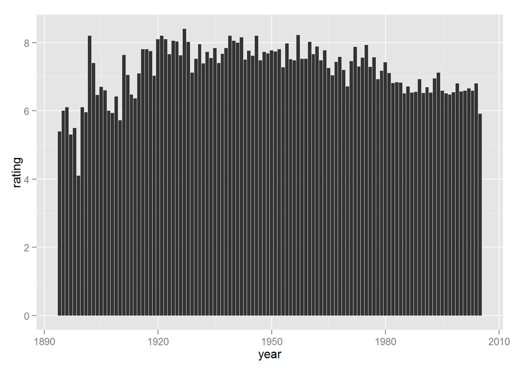